# Introduction

## Course: Programming and Data Management (EDI 3400)

### *Vegard H. Larsen (Department of Data Science and Analytics)*

## Syllabus

1. **Python for everybody: Exploring data using Python 3** by *Charles R. Severance*
2. **Introduction to Python for Econometrics, Statistics and Data Analysis** by *Kevin Sheppard*
3. **SQL queries for mere mortals: A hands-on guide to data manipulation in SQL** by *John L. Viescas*

## Notes on the Syllabus

**Severance:**

- Start with this book if you are new to Python.

**Sheppard:**

- This is a more advanced text.
- Note that this book is relying on Numpy being imported from the beginning of the text.
- We will not cover Numpy until a bit later in the course.
- Also, I will use Numpy in a slightly different way where Numpy is imported using the namespace `np`.
- If this is confusing, just ignore it for now.

**Viescas:**

- This book covers much more than we will use in this course.
- We will only cover topics from the first sections of this book.
- The rest is optional reading and a good reference for later use.

## Software we will use

- Much of the coding we will do in this course will be done using the Ed platform.
- You will interact with both Python and SQL through this platform using a web-browser and you do not need to install anything on your computer to use this platform.
- However, we will also use some other software that you will need to install on your computer.
- Managing to install this software is an important skill that you will need to learn in this course.

The additional software we will use is:

1. [Python](https://www.python.org) through the [Anaconda](https://www.anaconda.com/) distribution
2. [SQLite](https://www.sqlite.org/) - Is available with the Python installation
3. [DB Browser for SQLite](https://sqlitebrowser.org/)

## Course outline

**Today**: Introducing

**Lecture 2 - 5**: Programming with basic Python

**Lecture 6 - 8**: 3rd party Python libraries

**Lecture 9 - 10**: Advanced topics

**Lecture 11 - 13**: Databases with SQL and Python

**Lecture 14**: Summing up and Q&As

## Prerequisites and learning goals

No previous experience with programming is required.

**Learning goals:**

- Understand and be able to write computer programs in Python
- Be able to clean, visualize and analyze data using Python libraries
- Interact with data that is stored on disk or in an SQL database

# 1. Introduction to Programming, Python and the Jupyter Notebook

## Computer programming

- A computer program is a set of instructions that tells a computer how it can perform a specific task
- The instructions or recipe for a given task must be written in a programming language that a computer can understand and execute
- Many programming languages exist and they have different strengths and weaknesses (E.g., C, C++, Java, Matlab, R)
- We will use **Python** in this course

## What is Python?

- A high-level, general-purpose, interpreted programming language
- Developed by *Guido van Rossum* and first released in 1991
- Free and open source with a huge ecosystem of libraries
- Easy to learn compared to many other languages and also the most used programming language today (https://pypl.github.io/)
- Used for a wide variety of applications
  - E.g., Web development, games, data science, and automation

## Some challenges with learning Python?

- Can be run in many different ways on your computer which can be confusing for beginners
- It is possible (and common) to have more than one version of Python installed at the same time
  - This is usually an advantage but can create problems for beginners
- In some cases Python behaves differently on different operating systems (Windows vs. MacOS vs. Linux)

## The basic Python interpreter:

- Can be downloaded from: www.python.org
- Python is often pre-installed on macOS and Linux distributions
- The Python interpreter is used for running Python code
- Not the best way for us to interact with Python, but useful for some simple tasks allowing for fast and easy access to Python
- Python code files has the extension `.py`

## Installing Python using Anaconda

- We will use the Anaconda distribution to install Python
- Anaconda is specifically created for scientific computing
- Includes some important 3rd party libraries useful for data science
- Makes it easy to install and manage additional libraries
- - Anaconda also supports other languages such as [R](https://cran.r-project.org/) and [Julia](https://julialang.org/)

# 2. Working with the Jupyter Notebook

## [The Jupyter Notebook](https://jupyter.org/)

- This will be our main tool for Python programming in this course
- The Jupyter Notebook is installed together with the Anaconda distribution
- Access to Python through a web-browser such as Chrome
- It allows us to run each piece of the code individually and make modifications and see the results right next to the code

## Other related and complementary tools

These are available with Anaconda but will not get much attention (if any) in this course:

- [IPython](https://ipython.org/) - Command shell for interactive computing
- [Spyder](https://www.spyder-ide.org/) - Integrated Development Environment (IDE) for scientific programming in Python
- [JupyterLab](https://jupyterlab.readthedocs.io/) - Web-based user interface for Project Jupyter
- [VSCode](https://code.visualstudio.com/) - Code editor with support for Jupyter Notebooks
- [PyCharm](https://www.jetbrains.com/pycharm/) - One of the most popular Python IDEs

## Modality

The Jupyter Notebook has a modal user interface meaning that the keyboard has different functions depending on which mode the Notebook is in.

The Jupyter Notebook has two modes:

- **Command mode (blue cell border)**
  - We can edit the whole notebook, but not type into individual cells
- **Edit mode (green cell border)**
  - We can type into the cell, like a normal text editor

## Different types of cells

A Jupyter Notebook can in principle show all types of output that can be displayed in a web browser.

- Code cells (for running your code)
- Markdown cells (useful for documenting your code with Markdown)
- Raw cells (not evaluated by the Notebook)

## Running code:

- Run code by pressing Shift-Enter, or by clicking the "Play" on the toolbar, or you can use the drop-down menu Cell and select Run Cells
- Python code is being executed one line at a time, and also one cell at a time
- In a Python script it is very straight forward to see the order of execution by reading the script from top to bottom
- In a Notebook this can be a bit messy if cells are not executed in the correct order since we can run cells in an arbitrary order

## Code cells and comments

```python
# This is a code-cell
# Everything after the # is a comment and is ignored by Python

#Lets run some Python code
print('Hello World.....?')
```

```
Hello World.....?
```

```python
"""
This is a comment that can extend over several lines.
The comment is ignored by Python, but the Jupyter Notebook prints it out
"""
```

```
' \nThis is a comment that can extend over several lines.\nThe comment is ignored by Python, but the Jupyter Notebook prints it out\n'
```

```python
%run files/hello_world.py
```

```
Hello world!
36
```

# This is a level 1 heading

### This is a level 3 heading

Add emphasis **bold** and **bold**, or *italic* and *italic*.

- Sometimes we want to include lists.
- Which can be bulleted using asterisks.

[It is possible to include hyperlinks](https://www.example.com)

We can also include equations: $$ \hat{\beta} = \frac{\sum_i x_iy_i}{\sum_i x_i^2}$$

## Relying on libraries and 3rd party packages

- Pure Python can help us solve many problems but often we will need some additional and more advances functionality
- The Standard Python library gives us additional functionality, and is included when we install the basic python interpreter e.g.,
  - **[math](https://docs.python.org/3/library/math.html)** - Mathematical functions like `sqrt`, `log` and `sin`
  - **[re](https://docs.python.org/3/library/re.html)** - Regular expression matching for working with text
  - **[os](https://docs.python.org/3/library/os.html)** - Operating system dependent functionality
  - **[sqlite3](https://docs.python.org/3/library/sqlite3.html)** - A lightweight disk-based SQL database

## We will use some powerful third party libraries

If the functionality we need is not in the Standard library we can rely on 3rd party libraries.

- **[Numpy](https://numpy.org/)** - Numerical computing and linear algebra
- **[Pandas](https://pandas.pydata.org/)** - Excel like functionality with data frames
- **[Matplotlib](https://matplotlib.org/)** - Plotting and graphics
- **[Seaborn](https://seaborn.pydata.org/)** - Plotting and graphics

# 4. Examples of what we can do with Python

```python
# Taking the square root of a number
import math
math.sqrt(16)
```

```
4.0
```

```python
# Search for a specific term in a string
import re
txt = "How can we find all instances of the term 'in' in this sentence"
x = re.findall("in", txt)
x
```

```
['in', 'in', 'in', 'in']
```

```python
# Interact with the operating sytem
import os

os.name # windows will return 'nt' while  mac and linux will return 'posix'
```

```
'posix'
```

```python
import sqlite3
con = sqlite3.connect('example.db')
```

## Numpy example

```python
# Creating an array of numbers and calculating the mean of those numbers

# The as np portion of the code tells Python to give NumPy the alias of np.
# This allows you to use NumPy functions by simply typing np.
# The alias does not need to be np, but this is commonly used
import numpy as np
```

```python
a = np.array([2, 3, 4])
a.mean()
```

```
3.0
```

## Pandas example

```python
# Importing an excel file into Pandas

# Pandas is commonly imported as pd
import pandas as pd
```

```python
data = pd.read_excel('files/example_sales.xlsx')
```

```python
data
```

|  | Year | Sales | Best month |
| --- | --- | --- | --- |
| 0 | 2016 | 150000 | December |
| 1 | 2017 | 160000 | December |
| 2 | 2018 | 159000 | August |
| 3 | 2019 | 183000 | December |
| 4 | 2020 | 160000 | November |
| 5 | 2021 | 181000 | November |
| 6 | 2022 | 201000 | December |

## Matplotlib example

```python
# Let's  plot the sales data imported by Pandas with Matplotlib
import matplotlib.pyplot as plt # Matplotlib is commonly imported as plt
```

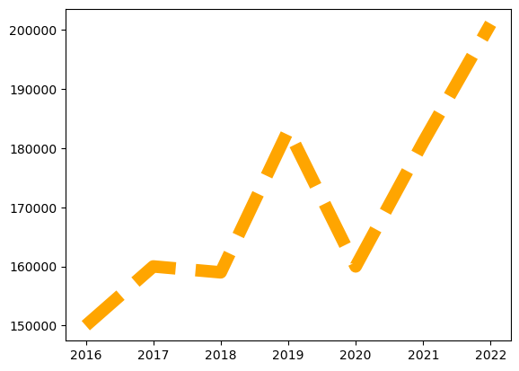

```python
plt.plot(data['Year'], data['Sales'], linestyle='--', lw=10, color='orange')
plt.show() # We plot the year on the x-axis and the sales data on the y-axis
```

## Other usefull 3rd party libraries not covered in this course

- **[SciPy](https://scipy.org/)** - Scientific and technical computing
- **[Scikit-Learn](https://scikit-learn.org/)** - Machine learning with various classification, regression and clustering algorithms
- **[NLTK](https://www.nltk.org/)** - Programs to work with human language data
- **[BeautifulSoup](https://beautiful-soup-4.readthedocs.io/en/latest/)** - Popular library for web crawling and data scraping
- **[TensorFlow](https://www.tensorflow.org/)** - Deep learning
- **[Numba](https://numba.pydata.org/)** and **[Cython](https://cython.org/)** - Translates Python code into fast machine code